# Module 2, Part 2: Random vectors, covariance, multivariate Normal distribution

TMA4268 Statistical Learning V2022

Sara Martino, Department of Mathematical Sciences, NTNU

January 20, 2022

# Overview

- Random vectors
- The covariance and correlation matrix
- The multivariate normal distribution

# Random vector

- A random vector $\boldsymbol{X}_{(p\times 1)}$ is a $p$-dimensional vector of random variables. For example
  - Weight of cork deposits in $p=4$ directions (N, E, S, W).
  - Factors to predict body fat: bmi, age, weight, hip circumference,….
- Joint distribution function: $f(\boldsymbol{x})$.
- From joint distribution function to marginal (and conditional distributions).
  $$f_1(x_1)=\int_{-\infty}^{\infty}\cdots
  \int_{-\infty}^{\infty} f(x_1,x_2,\ldots,x_p)dx_2 \cdots
  dx_p$$
- Cumulative distribution (definite integrals!) used to calculate probabilites.

## Moments

The moments are important properties of the distribution of $\boldsymbol{X}$. We will look at:

- E: Mean of random vector and random matrices.
- Cov: Covariance matrix.
- Corr: Correlation matrix.
- E and Cov of multiple linear combinations.

### The Cork deposit data

$~$

- Classical multivariate data set from Rao (1948).
- Weigth of bark deposits of $n=28$ cork trees in $p=4$ directions (N, E, S, W).

$~$

```r
corkds=as.matrix(
  read.table("https://www.math.ntnu.no/emner/TMA4268/2019v/data/corkMKB.txt")
  )
dimnames(corkds)[[2]]=c("N","E","S","W")
head(corkds)
```

```
##       N  E  S  W
## [1,] 72 66 76 77
## [2,] 60 53 66 63
## [3,] 56 57 64 58
## [4,] 41 29 36 38
## [5,] 32 32 35 36
## [6,] 30 35 34 26
```

```r
dim(corkds)
```

```
## [1] 28  4
```

Look at the data (always the first thing to do):

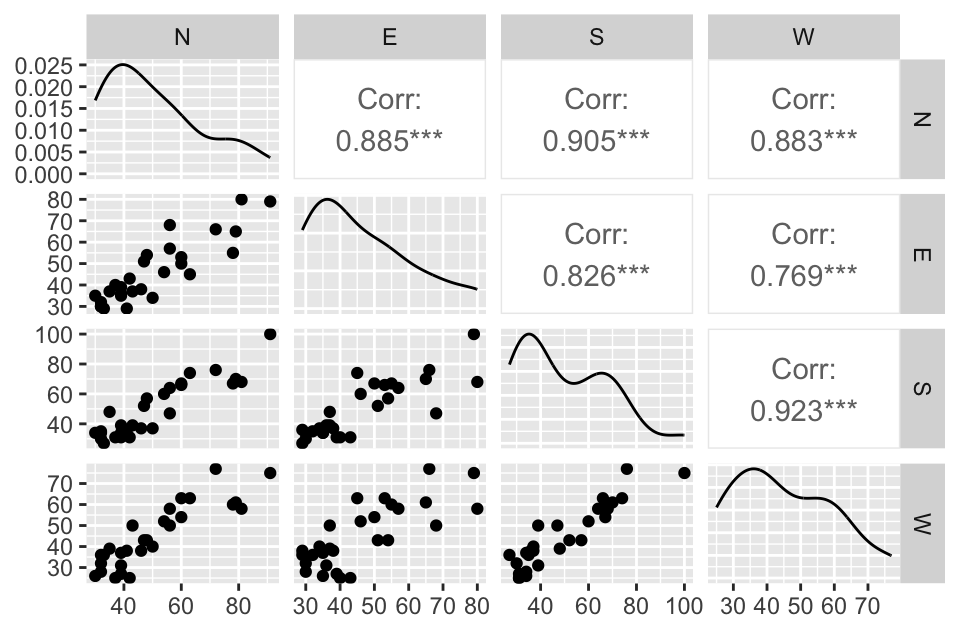

```r
library(GGally)
corkds <- as.data.frame(corkds)
ggpairs(corkds)
```

- Here we have a random sample of $n=28$ cork trees from the population and observe a $p=4$ dimensional random vector for each tree.
- This leads us to the definition of random vectors and a random matrix for cork trees:

$$\boldsymbol{X}_{(28 \times 4)}=\left[
\begin{array}{cccc}X_{11} & X_{12} & X_{13}& X_{14}\\ X_{21}
& X_{22} & X_{23}& X_{24}\\ X_{31} & X_{32} &
X_{33}& X_{34}\\ \vdots & \vdots & \ddots & \vdots\\
X_{28,1} & X_{28,2} & X_{28,3}& X_{28,4}\\ \end{array}
\right]$$

## Rules for means

$~$

- Random vector $\boldsymbol{X}_{(p\times 1)}$ with mean vector $\boldsymbol{\mu}_{(p\times 1)}$:

$$\boldsymbol{X}_{(p\times 1)}=\left[
\begin{array}{c}X_1\\ X_2\\ \vdots\\ X_p\\ \end{array}\right], \text{
and }\boldsymbol{\mu}_{(p \times 1)}=\text{E}(\boldsymbol{X})=\left[
\begin{array}{c}\text{E}(X_1)\\ \text{E}(X_2)\\ \vdots\\ \text{E}(X_p)\\
\end{array}\right] \ .$$

- Same rule for random matrices.
- Random matrix $\boldsymbol{X}_{(n\times p)}$ and random matrix $\boldsymbol{Y}_{(n\times p)}$:
  $$\text{E}(\boldsymbol{X}+\boldsymbol{Y})=\text{E}(\boldsymbol{X})+\text{E}(\boldsymbol{Y})
  \ .$$

(Rules of vector addition)

- Random matrix $\boldsymbol{X}_{(n\times p)}$ and conformable constant matrices $\boldsymbol{A}$ and $\boldsymbol{B}$:
  $$\text{E}(\boldsymbol{A}\boldsymbol{X}\boldsymbol{B})=\boldsymbol{A}\text{E}(\boldsymbol{X})\boldsymbol{B}$$

Proof: Board

**Q**:

- What are the univariate analogue to the formulas on the previous two slides (which you studied in your first introductory course in statistics)?

## The covariance

- What is the covariance called when $i=j$?
- What does it mean when the covariance is
  - negative
  - zero
  - positive?

Make a scatter plot for negative, zero and positive correlation (see also R example).

## Variance-covariance matrix

- Consider random vector $\boldsymbol{X}_{(p\times 1)}$ with mean vector $\boldsymbol{\mu}_{(p\times 1)}$:
  $$\boldsymbol{X}_{(p\times 1)}
  =\left[ \begin{array}{c} X_1\\ X_2\\ \vdots\\ X_p\\ \end{array} \right],
  \text{ and }\boldsymbol{\mu}_{(p\times 1)}
  =\text{E}(\boldsymbol{X})=\left[ \begin{array}{c} \text{E}(X_1)\\
  \text{E}(X_2)\\ \vdots\\ \text{E}(X_p)\\
  \end{array}\right]$$
- Variance-covariance matrix $\boldsymbol\Sigma$ (real and symmetric)
  $$\begin{align*}
  \boldsymbol\Sigma & =\text{Cov}(\boldsymbol{X})
  =\text{E}[(\boldsymbol{X}-\boldsymbol{\mu})(\boldsymbol{X}-\boldsymbol{\mu})^T]
  \\
  & = \left[ \begin{array}{cccc} \sigma_{1}^2 & \sigma_{12} &
  \cdots & \sigma_{1p}\\ \sigma_{12} & \sigma_{2}^2 & \cdots
  & \sigma_{2p}\\ \vdots & \vdots & \ddots & \vdots\\
  \sigma_{1p} & \sigma_{2p} & \cdots & \sigma_{p}^2\\
  \end{array} \right]
  =
  \text{E}(\boldsymbol{X}\boldsymbol{X}^T)-\boldsymbol{\mu}\boldsymbol{\mu}^T
  \end{align*}$$
- The diagonal elements in $\boldsymbol\Sigma$, $\sigma_{ii}=\sigma_i^2$, are variances.
- The off-diagonal elements are covariances $\sigma_{ij}=\text{E}[(X_i-\mu_i)(X_j-\mu_j)]=\sigma_{ji}$.
- $\boldsymbol\Sigma$ is called variance, covariance and variance-covariance matrix and denoted both $\text{Var}(\boldsymbol{X})$ and $\text{Cov}(\boldsymbol{X})$.

### Exercise: the variance-covariance matrix

Let $\boldsymbol{X}_{4\times 1}$ have variance-covariance matrix
$$\boldsymbol\Sigma= \left[ \begin{array}{cccc}
2&1&0&0\\
1&2&0&1\\
0&0&2&1\\
0&1&1&2\\
\end{array}
\right].$$

Explain what this means.

### Correlation matrix

$~$

Correlation matrix $\boldsymbol{\rho}$ (real and symmetric)
$$\boldsymbol{\rho}=\left[
\begin{array}{cccc}
\frac{\sigma_{1}^2}{\sqrt{\sigma_{1}^2\sigma_{1}^2}} &
\frac{\sigma_{12}}{\sqrt{\sigma_{1}^2\sigma_{2}^2}} &
\cdots &
\frac{\sigma_{1p}}{\sqrt{\sigma_{1}^2\sigma_{p}^2}}\\
\frac{\sigma_{12}}{\sqrt{\sigma_{1}^2\sigma_{2}^2}} &
\frac{\sigma_{2}^2}{\sqrt{\sigma_{2}^2\sigma_{2}^2}} &
\cdots &
\frac{\sigma_{2p}}{\sqrt{\sigma_{2}^2\sigma_{p}^2}}\\
\vdots & \vdots & \ddots & \vdots\\
\frac{\sigma_{1p}}{\sqrt{\sigma_{1}^2\sigma_{p}^2}} &
\frac{\sigma_{2p}}{\sqrt{\sigma_{2}^2\sigma_{p}^2}} &
\cdots &
\frac{\sigma_{p}^2}{\sqrt{\sigma_{p}^2\sigma_{p}^2}}\\
\end{array}\right]=
\left[ \begin{array}{cccc}
1 & \rho_{12} & \cdots & \rho_{1p}\\
\rho_{12} & 1 & \cdots & \rho_{2p}\\
\vdots & \vdots & \ddots & \vdots\\
\rho_{1p} & \rho_{2p} & \cdots & 1\\
\end{array}\right]$$

$$\boldsymbol{\rho}=(\boldsymbol{V}^{\frac{1}{2}})^{-1}
\boldsymbol\Sigma(\boldsymbol{V}^{\frac{1}{2}})^{-1},
\text{ where }
\boldsymbol{V}^{\frac{1}{2}}=
\left[ \begin{array}{cccc}
\sqrt{\sigma_{1}^2} & 0& \cdots & 0\\
0 & \sqrt{\sigma_{2}^2} & \cdots & 0\\
\vdots & \vdots & \ddots & \vdots\\
0 & 0 & \cdots & \sqrt{\sigma_{p}^2} \\
\end{array} \right]$$

### Exercise: the correlation matrix

$~$

Let $\boldsymbol{X}_{4\times 1}$ have variance-covariance matrix
$$\boldsymbol\Sigma= \left[ \begin{array}{cccc}
2&1&0&0\\
1&2&0&1\\
0&0&2&1\\
0&1&1&2\\
\end{array}
\right].$$
Find the correlation matrix.

**A**:

### Linear combinations

$~$

Consider a random vector $\boldsymbol{X}_{(p\times 1)}$ with mean vector $\boldsymbol{\mu}=\text{E}(\boldsymbol{X})$ and variance-covariance matrix $\boldsymbol\Sigma=\text{Cov}(\boldsymbol{X})$.

The linear combinations
$$\boldsymbol{Z}=\boldsymbol{C}\boldsymbol{X}=\left[
\begin{array}{c} \sum_{j=1}^p c_{1j}X_j\\ \sum_{j=1}^p c_{2j}X_j\\
\vdots \\ \sum_{j=1}^p c_{kj}X_j \end{array} \right]$$
have
$$\text{E}(\boldsymbol{Z})=\text{E}(\boldsymbol{C}\boldsymbol{X})=\boldsymbol{C}\boldsymbol{\mu}$$
$$\text{Cov}(\boldsymbol{Z})=\text{Cov}(\boldsymbol{C}\boldsymbol{X})=
\boldsymbol{C}\boldsymbol\Sigma\boldsymbol{C}^T$$

**Exercise:** Follow the proof (board) - what are the most important transitions?

### Exercise: Linear combinations

$$\boldsymbol{X}=\left[ \begin{array}{c}
X_N\\
X_E\\
X_S\\
X_W\\
\end{array}
\right],
\boldsymbol{\mu}=\left[
\begin{array}{c} \mu_N\\
\mu_E\\
\mu_S\\
\mu_W\\
\end{array}
\right], \text{ and } \boldsymbol\Sigma=\left[
\begin{array}{cccc}
\sigma_{N}^2 & \sigma_{NE} & \sigma_{NS} & \sigma_{NW}\\
\sigma_{NE} & \sigma_{E}^2 & \sigma_{ES}& \sigma_{EW}\\
\sigma_{NS} & \sigma_{SE} & \sigma_{S}^2 &
\sigma_{SW}\\
\sigma_{NW} & \sigma_{EW} & \sigma_{SW} & \sigma_{W}^2\\
\end{array} \right]$$

Scientists would like to compare the following three *contrasts*: N-S, E+W and (E+W)-(N+S), and define a new random vector $\boldsymbol{Y}_{(3\times 1)}=\boldsymbol{C}_{(3\times 4)} \boldsymbol{X}_{(4\times 1)}$ giving the three contrasts.

- Write down $\boldsymbol{C}$.
- Explain how to find $\text{E}(Y_1)$ and $\text{Cov}(Y_1,Y_3)$.
- Use R to find the mean vector, covariance matrix and correlations matrix of $\boldsymbol{Y}$, when the mean vector and covariance matrix for $\boldsymbol{X}$ given below.

```r
corkds <- as.matrix(read.table("https://www.math.ntnu.no/emner/TMA4268/2019v/data/corkMKB.txt"))
dimnames(corkds)[[2]] <- c("N","E","S","W")
mu=apply(corkds,2,mean)
mu
Sigma=var(corkds)
Sigma
```

```
##        N        E        S        W
## 50.53571 46.17857 49.67857 45.17857
##          N        E        S        W
## N 290.4061 223.7526 288.4378 226.2712
## E 223.7526 219.9299 229.0595 171.3743
## S 288.4378 229.0595 350.0040 259.5410
## W 226.2712 171.3743 259.5410 226.0040
```

```r
(C <- matrix(c(1,0,-1,0,0,1,0,1,-1,1,-1,1),byrow=T,nrow=3))
```

```
##      [,1] [,2] [,3] [,4]
## [1,]    1    0   -1    0
## [2,]    0    1    0    1
## [3,]   -1    1   -1    1
```

```r
C %*% Sigma %*% t(C)
```

```
##           [,1]       [,2]       [,3]
## [1,]  63.53439  -38.57672   21.02116
## [2,] -38.57672  788.68254 -149.94180
## [3,]  21.02116 -149.94180  128.71958
```

### The covariance matrix - more requirements?

$~$

Random vector $\boldsymbol{X}_{(p\times 1)}$ with mean vector $\boldsymbol{\mu}_{(p\times 1)}$ and covariance matrix
$$\boldsymbol\Sigma=\text{Cov}(\boldsymbol{X})=\text{E}[(\boldsymbol{X}-\boldsymbol{\mu})(\boldsymbol{X}-\boldsymbol{\mu})^T]=
\left[ \begin{array}{cccc}
\sigma_{1}^2 & \sigma_{12} & \cdots & \sigma_{1p}\\
\sigma_{12} & \sigma_{2}^2 & \cdots & \sigma_{2p}\\
\vdots & \vdots & \ddots & \vdots\\
\sigma_{1p} & \sigma_{2p} & \cdots & \sigma_{p}^2\\
\end{array} \right]$$

- The covariance matrix is by construction symmetric, and it is common to require that the covariance matrix is positive semidefinite. This means that, for every vector $\boldsymbol{b}\neq \boldsymbol{0}$

$$\boldsymbol{b}^T \boldsymbol{\Sigma}
\boldsymbol{b} \geq 0 \ .$$

- Why do you think that is?

$~$

Hint: Is it possible that the variance of the linear combination $\boldsymbol{Y}=\boldsymbol{b}^T\boldsymbol{X}$ is negative?

## Random vectors - Single-choice exercise

Quizz on www.menti.com, code 3967 5773

### Question 1: Mean of sum

$\boldsymbol{X}$ and $\boldsymbol{Y}$ are two bivariate random vectors with $\text{E}(\boldsymbol{X})=(1,2)^T$ and $\text{E}(\boldsymbol{Y})=(2,0)^T$. What is $\text{E}(\boldsymbol{X}+\boldsymbol{Y})$?

$~$

- A: $(1.5,1)^T$
- B: $(3,2)^T$
- C: $(-1,2)^ T$
- D: $(1,-2)^T$

### Question 2: Mean of linear combination

$\boldsymbol{X}$ is a 2-dimensional random vector with $\text{E}(\boldsymbol{X})=(2,5)^T$ , and $\boldsymbol{b}=(0.5, 0.5)^T$ is a constant vector. What is $\text{E}(\boldsymbol{b}^T\boldsymbol{X})$?

$~$

- A: 3.5
- B: 7
- C: 2
- D: 5

### Question 3: Covariance

$\boldsymbol{X}$ is a $p$-dimensional random vector with mean $\boldsymbol{\mu}$. Which of the following defines the covariance matrix?

$~$

- A: $E[(\boldsymbol{X}-\boldsymbol{\mu})^T(\boldsymbol{X}-\boldsymbol{\mu})]$
- B: $E[(\boldsymbol{X}-\boldsymbol{\mu})(\boldsymbol{X}-\boldsymbol{\mu})^T]$
- C: $E[(\boldsymbol{X}-\boldsymbol{\mu})(\boldsymbol{X}-\boldsymbol{\mu})]$
- D: $E[(\boldsymbol{X}-\boldsymbol{\mu})^T(\boldsymbol{X}-\boldsymbol{\mu})^T]$

### Question 4: Mean of linear combinations

$\boldsymbol{X}$ is a $p$-dimensional random vector with mean $\boldsymbol{\mu}$ and covariance matrix $\boldsymbol\Sigma$. $\boldsymbol{C}$ is a constant matrix. What is then the mean of the $k$-dimensional random vector $\boldsymbol{Y}=\boldsymbol{C}\boldsymbol{X}$?

$~$

- A: $\boldsymbol{C}\boldsymbol{\mu}$
- B: $\boldsymbol{C}\boldsymbol\Sigma$
- C: $\boldsymbol{C}\boldsymbol{\mu}\boldsymbol{C}^T$
- D: $\boldsymbol{C}\boldsymbol\Sigma\boldsymbol{C}^T$

### Question 5: Covariance of linear combinations

$\boldsymbol{X}$ is a $p$-dimensional random vector with mean $\boldsymbol{\mu}$ and covariance matrix $\boldsymbol\Sigma$. $\boldsymbol{C}$ is a constant matrix. What is then the covariance of the $k$-dimensional random vector $\boldsymbol{Y}=\boldsymbol{C}\boldsymbol{X}$?

$~$

- A: $\boldsymbol{C}\boldsymbol{\mu}$
- B: $\boldsymbol{C}\boldsymbol\Sigma$
- C: $\boldsymbol{C}\boldsymbol{\mu}\boldsymbol{C}^T$
- D: $\boldsymbol{C}\boldsymbol\Sigma\boldsymbol{C}^T$

### Question 6: Correlation

$\boldsymbol{X}$ is a $2$-dimensional random vector with covariance matrix
$$\boldsymbol\Sigma=
\left[\begin{array}{cc}
4 & 0.8 \\
0.8 & 1\\
\end{array}
\right]$$
Then the correlation between the two elements of $\boldsymbol{X}$ are:

$~$

- A: 0.10
- B: 0.25
- C: 0.40
- D: 0.80

# The multivariate normal distribution

Why is the mvN so popular?

- Many natural phenomena may be modelled using this distribution (just as in the univariate case).
- Multivariate version of the central limit theorem- the sample mean will be approximately multivariate normal for large samples.
- Good interpretability of the covariance.
- Mathematically tractable.
- Building block in many models and methods.

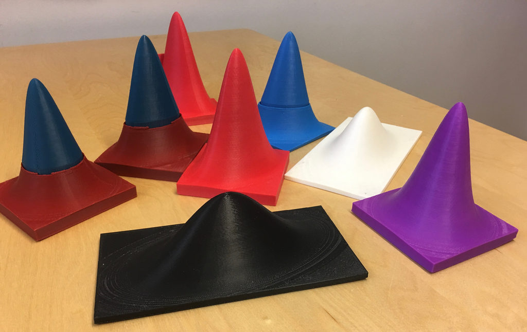

3D multivariate Normal distributions

3D multivariate Normal distributions

## The multivariate normal (mvN) pdf

The random vector $\boldsymbol{X}_{p\times 1}$ is multivariate normal $N_p$ with mean $\boldsymbol{\mu}$ and (positive definite) covariate matrix $\boldsymbol\Sigma$. The pdf is:

$$f(\boldsymbol{x})=\frac{1}{(2\pi)^\frac{p}{2}|\boldsymbol\Sigma|^\frac{1}{2}}
\exp\{-\frac{1}{2}(\boldsymbol{x}-\boldsymbol{\mu})^T\boldsymbol\Sigma^{-1}(\boldsymbol{x}-\boldsymbol{\mu})\}$$
$~$

**Questions**:

- How does this compare to the univariate version?
  $$f(x)=\frac{1}{\sqrt{2\pi}\sigma}\exp\{-
  \frac{1}{2\sigma^2}(x-\mu)^2\}$$
- Why do we need the constant in front of the $\exp$?
- What is the dimension of the part in $\exp$?
- What happens if the determinant $|\boldsymbol\Sigma| = 0$ (degenerate case)?

## Four useful properties of the mvN

Let $\boldsymbol{X}_{(p\times 1)}$ be a random vector from $N_p(\boldsymbol{\mu},\boldsymbol\Sigma)$.

1. The grapical contours of the mvN are ellipsoids (can be shown using spectral decomposition).
2. Linear combinations of components of $\boldsymbol{X}$ are (multivariate) normal.
3. All subsets of the components of $\boldsymbol{X}$ are (multivariate) normal (special case of the above).
4. Zero covariance implies that the corresponding components are independently distributed (in contrast to general distributions).

$~$

If you need a refresh, you might find that video useful: https://www.youtube.com/watch?v=eho8xH3E6mE

All of these are proven in TMA4267 Linear Statistical Models.

The result 4 is rather useful! If you have a bivariate normal and observed covariance 0, then your variables are independent.

## Contours of multivariate normal distribution

- Contours of constant density for the $p$-dimensional normal distribution are ellipsoids defined by $\boldsymbol{x}$ such that
  $$(\boldsymbol{x}-\boldsymbol{\mu})^T\boldsymbol\Sigma^{-1}(\boldsymbol{x}-\boldsymbol{\mu})=b$$
  where $b>0$ is a constant.
- These ellipsoids are centered at $\boldsymbol{\mu}$ and have axes $\pm \sqrt{b \lambda_i}\boldsymbol{e}_i$, where $\boldsymbol\Sigma\boldsymbol{e}_i=\lambda_i \boldsymbol{e}_i$ (eigenvector for $\lambda_i$), for $i=1,...,p$.
- To see this the spectral decomposition of the covariance matrix is useful.

Note:

*In M4: Classification the mvN is very important and we will often draw contours of the mvN as ellipses (in 2D space). This is the reason why we do that.*

## Identify the mvNs from their contours

Let $\boldsymbol\Sigma=\left[\begin{array}{cc} \sigma_x^2 & \rho\sigma_{x}\sigma_{y}\\\rho\sigma_{x}\sigma_{y}&\sigma_y^2\\ \end{array} \right]$.

The following four figure contours have been generated:

- 1: $\sigma_x=1$, $\sigma_y=2$, $\rho=-0.3$
- 2: $\sigma_x=1$, $\sigma_y=1$, $\rho=0$
- 3: $\sigma_x=1$, $\sigma_y=1$, $\rho=0.5$
- 4: $\sigma_x=1$, $\sigma_y=2$, $\rho=0$

**Match the distributions to the figures on the next slide.**

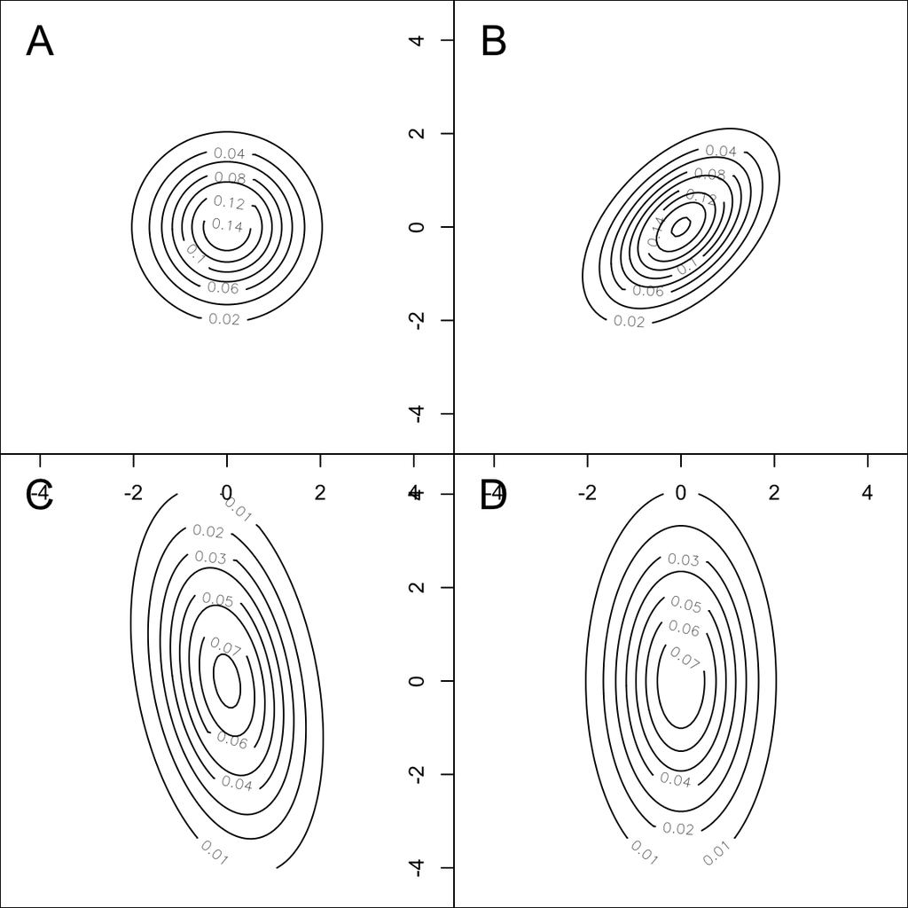

Take a look at the contour plots - when are the contours circles, when ellipses?

## Multiple choice - multivariate normal

A second quizz on www.menti.com, code 3967 5773

Choose the correct answer. Let’s go!

### Question 1: Multivariate normal pdf

The probability density function is $(\frac{1}{2\pi})^\frac{p}{2}\det(\boldsymbol\Sigma)^{-\frac{1}{2}}\exp\{-\frac{1}{2}Q\}$ where $Q$ is

- A: $(\boldsymbol{x}-\boldsymbol{\mu})^T\boldsymbol\Sigma^{-1}(\boldsymbol{x}-\boldsymbol{\mu})$
- B: $(\boldsymbol{x}-\boldsymbol{\mu})\boldsymbol\Sigma(\boldsymbol{x}-\boldsymbol{\mu})^T$
- C: $\boldsymbol\Sigma-\boldsymbol{\mu}$

### Question 2: Trivariate normal pdf

What graphical form has the solution to $f(\boldsymbol{x})=$ constant?

- A: Circle
- B: Parabola
- C: Ellipsoid
- D: Bell shape

### Question 3: Multivariate normal distribution

$\boldsymbol{X}_p \sim N_p(\boldsymbol{\mu},\boldsymbol\Sigma)$, and $\boldsymbol{C}$ is a $k \times p$ constant matrix. $\boldsymbol{Y}=\boldsymbol{C}\boldsymbol{X}$ is

- A: Chi-squared with $k$ degrees of freedom
- B: Multivariate normal with mean $k\boldsymbol{\mu}$
- C: Chi-squared with $p$ degrees of freedom
- D: Multivariate normal with mean $\boldsymbol{C}\boldsymbol{\mu}$

### Question 4: Independence

Let $\boldsymbol{X}\sim N_3(\boldsymbol{\mu},\boldsymbol\Sigma)$, with
$$\boldsymbol\Sigma= \left[
\begin{array}{ccc} 1&1&0\\
1&3&2\\
0&2&5\\
\end{array}
\right].$$
Which two variables are independent?

- A: $X_1$ and $X_2$
- B: $X_1$ and $X_3$
- C: $X_2$ and $X_3$
- D: None – but two are uncorrelated.

### Question 5: Constructing independent variables?

Let $\boldsymbol{X}\sim N_p(\boldsymbol{\mu},\boldsymbol\Sigma)$. How can I construct a vector of independent standard normal variables from $\boldsymbol{X}$?

- A: $\boldsymbol\Sigma(\boldsymbol{X}-\boldsymbol{\mu})$
- B: $\boldsymbol\Sigma^{-1}(\boldsymbol{X}+\boldsymbol{\mu})$
- C: $\boldsymbol\Sigma^{-\frac{1}{2}}(\boldsymbol{X}-\boldsymbol{\mu})$
- D: $\boldsymbol\Sigma^{\frac{1}{2}}(\boldsymbol{X}+\boldsymbol{\mu})$

# Further reading/resources

- [Videoes on YouTube by the authors of ISL, Chapter 2](https://www.youtube.com/playlist?list=PL5-da3qGB5IDvuFPNoSqheihPOQNJpzyy)

# Acknowledgements

Thanks to Mette Langaas, who developed the first slide set in 2018 and 2019, and to Julia Debik for contributing to this module.